# Homework 3 Solutions

*Answers are shown in red beneath each question.*

# Part I: Definitions

$\bf (1)$ Define the following terms/concepts.

1. Describe the central limit theorem and its significance to the sampling distribution for a sample proportion or mean

The central limit theorem (CLT) states that the sampling distribution of the sample mean $\bar{x}$ (or the sample proportion $\hat{p}$) is approximately normal when the sample size is large enough, regardless of the shape of the population distribution. Its significance: it lets us use the normal distribution (the $Z$-table) to find probabilities about $\bar{x}$ and $\hat{p}$, and to build confidence intervals and significance tests for $\mu$ and $p$.

2. Standard error

The standard deviation of the sampling distribution of a statistic. It measures how much the statistic varies from sample to sample: $\sigma/\sqrt{n}$ for $\bar{x}$ and $\sqrt{p(1-p)/n}$ for $\hat{p}$.

3. Margin of error

The amount added to and subtracted from the point estimate in a confidence interval: the critical value times the standard error. It measures the precision of the estimate, how far the estimate might reasonably be from the true parameter.

4. Describe the “basic form” of a confidence interval

Point estimate $\pm$ critical value $\times$ standard error, which can also be written as point estimate $\pm$ margin of error.

5. Confidence level

The probability that the interval will contain the true parameter value **before** the data are gathered: the long-run proportion of intervals made this way that capture the parameter.

6. Critical value

The standard score ($z$ or $t$) that sets the number of standard errors in a confidence interval. In a significance test, it is the point on the distribution of the test statistic that marks the edge of the rejection region.

7. When are the $t$-distribution and the standard normal distribution approximately the same shape?

When the sample size is large (and so the degrees of freedom are large), typically $n$ greater than about 30.

8. How are the degrees of freedom of a $t$-distribution related to its shape?

As the degrees of freedom increase, the $t$-distribution becomes more like the standard normal distribution, with lighter tails. With few degrees of freedom it has heavier tails than the standard normal.

1. Null and alternative hypotheses

The null hypothesis $H_0$ is the claim being tested, usually “no effect” or “no change”: the parameter equals a specific value. The alternative hypothesis $H_A$ is what we suspect is true instead, that the parameter is less than, greater than, or not equal to that value.

10. Significance level

A threshold $\alpha$ chosen before the test that sets how much evidence is needed to reject the null hypothesis. We reject $H_0$ when the $p$-value is less than $\alpha$.

11. $p$-value

The probability, assuming the null hypothesis is true, of getting a test statistic at least as extreme as the one observed. A small $p$-value means the data would be unusual if $H_0$ were true.

12. Rejection region

The area in the tail (or tails) of the distribution of the test statistic for which a result is deemed statistically significant. If the test statistic falls in it, we reject $H_0$.

# Part II: Finding Normal Probabilities

$\bf (2)$ Let $Z$ be a standard normal random variable, $Z \sim N(0, 1)$. For each probability, sketch the curve, shade the area, and use the $Z$-table to find it.

1. $P(Z < 1.47)$

A lower tail is the table value itself: $P(Z < 1.47) = 0.9292$.

2. $P(Z > -0.62)$

An upper tail is one minus the table value: $P(Z > -0.62) = 1 - P(Z \leq -0.62) = 1 - 0.2676 = 0.7324$.

3. $P(Z > 2.15)$

$P(Z > 2.15) = 1 - P(Z \leq 2.15) = 1 - 0.9842 = 0.0158$.

4. $P(-1.20 < Z < 0.85)$

An area between is the larger table value minus the smaller one: $P(-1.20 < Z < 0.85) = 0.8023 - 0.1151 = 0.6872$.

5. $P(Z < -1.96 \text{ or } Z > 1.96)$

The two tails are the same size, so $P(Z < -1.96) + P(Z > 1.96) = 2(0.0250) = 0.0500$. This is the $5\%$ left outside a $95\%$ confidence interval.

$\bf (3)$ Assume the continuous random variable $X$ follows a normal distribution with mean $\mu = 25$ and variance $\sigma^2 = 16$.

The standard deviation is $\sigma = \sqrt{16} = 4$. Convert each value to a $z$-score with $z = (x - 25)/4$.

1. $P(X < 15)$

$z = (15 - 25)/4 = -2.5$, so $P(X < 15) = P(Z < -2.5) = 0.0062$.

2. $P(X > 28)$

$z = (28 - 25)/4 = 0.75$, so $P(X > 28) = 1 - P(Z \leq 0.75) = 1 - 0.7734 = 0.2266$.

3. $P(12 < X < 20)$

$z = (12 - 25)/4 = -3.25$ and $z = (20 - 25)/4 = -1.25$, so $P(12 < X < 20) = P(-3.25 < Z < -1.25) = 0.1056 - 0.0006 = 0.1050$.

4. $P(X > 30)$

$z = (30 - 25)/4 = 1.25$, so $P(X > 30) = 1 - 0.8944 = 0.1056$.

5. $P(25 < X < 33)$

$z = 0$ and $z = (33 - 25)/4 = 2$, so $P(25 < X < 33) = P(0 < Z < 2) = 0.9772 - 0.5000 = 0.4772$.

6. What is the value of $X$ that marks the $95th$ percentile of the distribution?

The $z$-score with $0.95$ to its left is about $z = 1.645$. Converting back, $x = \mu + z\sigma = 25 + 1.645(4) = 31.58$.

$\bf (4)$ Suppose that a random variable $X$ follows a normal distribution with mean $\mu = -5$ and standard deviation $\sigma = 1.8$. Using the plot of the $Z$-distribution below, shade in the area corresponding to the probability $P(-2 < X < 0.5)$.

Convert both ends: $z = (-2 - (-5))/1.8 = 1.67$ and $z = (0.5 - (-5))/1.8 = 3.06$. Shade the area under the standard normal curve between $Z = 1.67$ and $Z = 3.06$, a thin sliver in the right tail. (Its area is $0.9989 - 0.9525 = 0.0464$.)

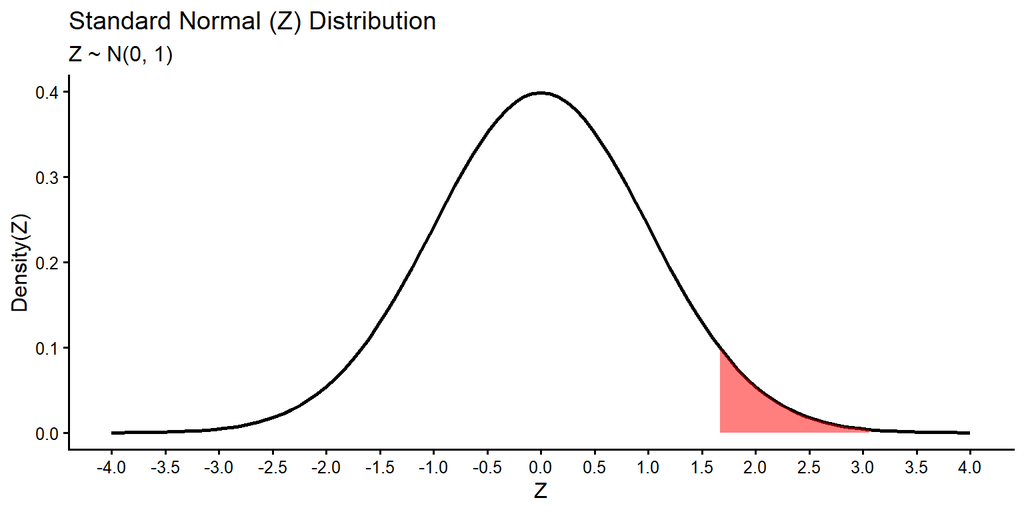

$\bf (5)$ Spotify song length: $\mu = 3.71$ minutes, $\sigma = 1.51$ minutes, skewed right.

1. Explain why you **cannot** use the $Z$-table to find the probability that one randomly chosen song is longer than 4 minutes.

The $Z$-table gives areas under a **normal** curve. A single song’s length follows the population distribution, which is skewed right, not normal, so a $z$-score and the $Z$-table would give the wrong probability.

2. A playlist is made of $n = 36$ songs chosen at random. Describe the sampling distribution of the playlist’s mean song length $\bar{x}$.

By the **central limit theorem**, $n = 36 \geq 30$ is large enough that $\bar{x}$ is approximately **normal**, even though song length is skewed. Its mean is $\mu = 3.71$ minutes and its standard error is $\sigma/\sqrt{n} = 1.51/\sqrt{36} = 1.51/6 \approx 0.252$ minutes.

3. Show how to compute $P(\bar{x} > 4)$.

Standardize with the standard error: $z = (4 - 3.71)/0.252 \approx 1.15$, so $P(\bar{x} > 4) = 1 - P(Z \leq 1.15) = 1 - 0.8749 = 0.1251$.

4. Show how to compute $P(\bar{x} < 3.5)$.

$z = (3.5 - 3.71)/0.252 \approx -0.83$, so $P(\bar{x} < 3.5) = P(Z < -0.83) = 0.2033$.

# Part III: Confidence Intervals

$\bf (6)$ Fill in the table below with the corresponding $\alpha$ level and critical value for each confidence interval for a population proportion.

| Confidence Level | $\alpha$ | critical value: $z_{1-\alpha/2}$ |
| --- | --- | --- |
| $90\%$ | $\color{red}{0.1}$ | $\color{red}{1.645}$ |
| $88\%$ | $\color{red}{0.12}$ | $\color{red}{1.555}$ |
| $97\%$ | $\color{red}{0.03}$ | $\color{red}{2.170}$ |
| $96\%$ | $\color{red}{0.04}$ | $\color{red}{2.054}$ |
| $78\%$ | $\color{red}{0.22}$ | $\color{red}{1.227}$ |
| $99\%$ | $\color{red}{0.01}$ | $\color{red}{2.576}$ |

For each row, $\alpha = 1 - \text{confidence level}$, and the critical value is the $z$-score with area $1 - \alpha/2$ to its left. For example, at $88\%$ confidence, $\alpha = 0.12$, so look up the area $0.94$ in the $Z$-table: $z \approx 1.555$.

$\bf (7)$ The $t$-distribution.

1. Fill in the table below with the corresponding $\alpha$ level and critical value for each confidence interval for a population mean when $\sigma$ is unknown.

| Confidence Level | Sample size | $\alpha$ | critical value: $t_{n-1, 1-\alpha/2}$ |
| --- | --- | --- | --- |
| $90\%$ | $n = 5$ | $\color{red}{0.1}$ | $\color{red}{2.132}$ |
| $85\%$ | $n = 8$ | $\color{red}{0.15}$ | $\color{red}{1.617}$ |
| $99\%$ | $n = 11$ | $\color{red}{0.01}$ | $\color{red}{3.169}$ |
| $99.9\%$ | $n = 14$ | $\color{red}{0.001}$ | $\color{red}{4.221}$ |
| $80\%$ | $n = 41$ | $\color{red}{0.2}$ | $\color{red}{1.303}$ |
| $95\%$ | $n = 13$ | $\color{red}{0.05}$ | $\color{red}{2.179}$ |

Use the $t$-table row for $n - 1$ degrees of freedom and the column for the confidence level. For example, at $90\%$ confidence with $n = 5$, read the row for 4 degrees of freedom: $t = 2.132$.

2. For each probability, use the $t$-table to give the two upper-tail areas it falls between, then use the course calculator to find its exact value.
- $P(t > 1.97)$ with 5 degrees of freedom: on the 5 df row, 1.97 falls between 1.699 (upper tail 0.075) and 2.015 (upper tail 0.05), so the probability is between 0.05 and 0.075. Exactly, $P(t > 1.97) = 0.053$.
- $P(t \leq 2.9)$ with 2 degrees of freedom: on the 2 df row, 2.9 falls between 2.920 (upper tail 0.05) and 2.282 (upper tail 0.075), so the upper tail is just over 0.05 and $P(t \leq 2.9)$ is just under 0.95. Exactly, $P(t \leq 2.9) = 0.949$.
- $P(t \geq -0.98)$ with 8 degrees of freedom: by symmetry this is $1 - P(t > 0.98)$. On the 8 df row, 0.98 falls between 0.889 (upper tail 0.2) and 1.108 (upper tail 0.15), so $P(t > 0.98)$ is between 0.15 and 0.2, and $P(t \geq -0.98)$ is between 0.8 and 0.85. Exactly, $P(t \geq -0.98) = 0.822$.
3. Look at the $t$-table row for 4 degrees of freedom and the $Z$-score row at the bottom. For a $95\%$ confidence interval, which critical value is larger? Explain why using $s$ in place of $\sigma$ calls for a larger critical value.

The $t$ critical value is larger: $t_{4, 0.975} = 2.776$ compared with $z = 1.960$. The sample standard deviation $s$ is itself an estimate that varies from sample to sample, which adds uncertainty. The heavier tails of the $t$-distribution make the interval wider to account for it, so that the interval still captures $\mu$ about $95\%$ of the time.

$\bf (8)$ Using the Georgia survey table, construct a $90\%$ confidence interval for the proportion of Independent college student voters in the state of Georgia.

```r
sample.size = (8+36+15)
estimate = 15/sample.size
confidence.lvl = 0.9

CI = one.sample.prop.CI(phat = estimate,
                        n = sample.size,
                        alpha = 1-confidence.lvl,
                        verbose = T)
```

```
## [1] --------------------------------------------------
## [1] Estimate = 0.2542
## [1] Critical Value  = 1.6449
## [1] Estimated Standard Error = 0.0567
## [1] Margin of error = 0.0932
## [1] 90 % CI = [0.161,0.3475]
## [1] --------------------------------------------------
```

$\hat{p} = 15/59 \approx 0.254$, and there are 15 successes and 44 failures, enough for the normal approximation. The interval is
$$0.254 \pm
1.645\sqrt{\frac{0.254(1 - 0.254)}{59}}, \quad \text{from about } 0.161
\text{ to } 0.347.$$
We estimate with $90\%$ confidence that between 16.1% and 34.7% of Georgia college students are Independents.

$\bf (9)$ Using the health club survey table, construct a $95\%$ confidence interval for the proportion of customers that are “very satisfied” or more.

```r
sample.size = (3+20+64+109+19)
very.satisfied = 109
completely.satisfied = 19
estimate = (very.satisfied+completely.satisfied)/sample.size
confidence.lvl = 0.95

CI = one.sample.prop.CI(phat = estimate,
                        n = sample.size,
                        alpha = 1-confidence.lvl,
                        verbose = T)
```

```
## [1] --------------------------------------------------
## [1] Estimate = 0.5953
## [1] Critical Value  = 1.96
## [1] Estimated Standard Error = 0.0335
## [1] Margin of error = 0.0656
## [1] 95 % CI = [0.5297,0.661]
## [1] --------------------------------------------------
```

$\hat{p} = (109 + 19)/215 = 128/215 \approx 0.595$. The interval is $0.595 \pm 1.96\sqrt{0.595(1 - 0.595)/215}$, from about **0.530 to 0.661**. We estimate with $95\%$ confidence that between 53.0% and 66.1% of club members are very or completely satisfied with their membership.

$\bf (10)$ Camp letters: $\sigma = 2.5$, $n = 20$, $\bar{x} = 7.9$, $s = 2.8$.

1. Both $\sigma$ and $s$ are given. Which one should you use, and should you use a $z$ or a $t$ critical value?

Use $\sigma = 2.5$ with a $z$ critical value. When the population standard deviation is **known**, the sampling distribution of $\bar{x}$ is $N(\mu, \sigma/\sqrt{n})$, and there is no need to estimate it with $s$. The $t$-distribution is for when $\sigma$ is unknown and $s$ takes its place. (Because $n = 20$ is less than 30, we rely on the population being approximately normal.)

2. Construct a $90\%$ confidence interval for the population mean number of letters campers send home.

The standard error is $\sigma/\sqrt{n} = 2.5/\sqrt{20} \approx 0.559$, and $z_{0.95} = 1.645$, so the margin of error is $1.645(0.559) \approx 0.92$. The interval is
$$7.9 \pm 0.92, \quad \text{from
} 6.98 \text{ to } 8.82 \text{ letters.}$$

3. Interpret the interval from part (b) in a complete sentence.

We estimate with $90\%$ confidence that the mean number of letters all campers send home during their session is between 6.98 and 8.82.

4. What would happen to the margin of error if $500$ campers were surveyed instead of $20$? Why?

It would shrink, to $1.645(2.5/\sqrt{500}) \approx 0.18$ letters. The standard error divides by $\sqrt{n}$, so a larger sample gives a smaller standard error and a narrower interval.

5. Which of the following statements describes what “$90\%$ confident” means?

The third: approximately $90\%$ of the intervals calculated from repeated samples would contain the true population mean. The first is wrong because each sample gives a different interval. The second is wrong because every interval contains its own sample mean (it is centered there). The fourth is wrong because the confidence level is about intervals capturing $\mu$, not about $\bar{x}$ equaling $\mu$, which almost never happens exactly.

$\bf (11)$ California housing, $n = 25$.

1. Construct and interpret a $95\%$ confidence interval for the average median family income for households in California in 1990.

```r
sample.size = 25
sample.mean = round(mean(hss$median_income), 2)*10000 #converting estimate to USD
sample.sd =  round(sd(hss$median_income), 2)*10000 #converting standard deviation to USD
confidence.lvl = 0.95

CI = one.sample.t.CI(xbar = sample.mean,
                     s = sample.sd,
                     n = sample.size,
                     alpha = 1 - confidence.lvl,
                     verbose = T)
```

```
## [1] --------------------------------------------------
## [1] Estimate = 37400
## [1] Critical Value  = 2.0639
## [1] Estimated Standard Error = 3080
## [1] Margin of error = 6356.8076
## [1] 95 % CI = [31043.1924,43756.8076]
## [1] --------------------------------------------------
```

$\sigma$ is unknown, so the interval uses $s$ and a $t$ critical value with $25 - 1 = 24$ degrees of freedom, $t_{24, 0.975} = 2.064$. At the $95\%$ confidence level, we estimate the average median family income in California in 1990 to be no less than $31,043 USD and no more than $43,757 USD. If we repeated this sampling procedure many times, $95\%$ of the intervals constructed this way would contain the true average.

2. Construct and interpret a $99\%$ confidence interval for the average number of bedrooms per block in California in 1990.

```r
sample.size = 25
sample.mean = round(mean(hss$total_bedrooms), 2)
sample.sd =  round(sd(hss$total_bedrooms), 2)
confidence.lvl = 0.99

CI = one.sample.t.CI(xbar = sample.mean,
                     s = sample.sd,
                     n = sample.size,
                     alpha = 1 - confidence.lvl,
                     verbose = T)
```

```
## [1] --------------------------------------------------
## [1] Estimate = 640.52
## [1] Critical Value  = 2.7969
## [1] Estimated Standard Error = 76.11
## [1] Margin of error = 212.8751
## [1] 99 % CI = [427.6449,853.3951]
## [1] --------------------------------------------------
```

With 24 degrees of freedom, $t_{24, 0.995} = 2.797$. At the $99\%$ confidence level, we estimate the average number of bedrooms per block in California in 1990 to be no less than 427.6 and no more than 853.4. If we repeated this sampling procedure many times, $99\%$ of the intervals constructed this way would contain the true average.

$\bf (12)$ Tranquilizer effective periods (hours): 2.7, 2.8, 3.0, 2.3, 2.3, 2.2, 2.8, 2.1, 2.4.

1. Show how to compute the sample mean $\bar{x}$ and sample standard deviation $s$.

$\bar{x} = \frac{2.7 + 2.8 + 3.0 + 2.3 + 2.3 + 2.2 + 2.8 + 2.1 + 2.4}{9} = \frac{22.6}{9} \approx 2.51$ hours, and
$$s = \sqrt{\frac{\sum (x_i -
\bar{x})^2}{n - 1}} = \sqrt{\frac{0.809}{8}} \approx 0.32 \text{ hours.}$$

2. Should you use a $z$ or a $t$ critical value for this interval?

A $t$ critical value with $n - 1 = 8$ degrees of freedom: $\sigma$ is unknown, so we estimate it with $s$. The sample is small, so we also rely on the stated assumption that the population is approximately normal.

3. Construct a $95\%$ confidence interval for the population mean length of time the tranquilizer lasts.

$t_{8, 0.975} = 2.306$ and the standard error is $s/\sqrt{n} = 0.32/\sqrt{9} \approx 0.107$, so
$$2.51 \pm
2.306(0.107) = 2.51 \pm 0.25, \quad \text{from about } 2.26 \text{ to }
2.76 \text{ hours.}$$

4. What does it mean to be “$95\%$ confident” in this problem?

If the researchers repeated the study many times with nine new patients each time and built an interval from each sample, about $95\%$ of those intervals would contain the true mean length of time the tranquilizer lasts. It does **not** mean there is a $95\%$ probability that the true mean is between 2.26 and 2.76 hours.

# Part IV: Choosing a Minimum Sample Size and Assumptions of Estimators

$\bf (13)$ Choosing a minimum sample size.

1. E-cigarette use, $p \approx 0.24$, $95\%$ confidence, margin of error $1.5\%$.

```r
m = 0.015 #desired margin of error
p = 0.24 #expected proportion of e-cigarette use based on Saudi Study
confidence.lvl = 0.95
alpha = 1 - confidence.lvl

z = qnorm(1 - alpha/2) #standard score for confidence level of 95%

n = ceiling((z^2*p*(1-p))/m^2) # compute sample size - always round UP
print(paste0('n = ', n, ' observations'))
```

```
## [1] "n = 3115 observations"
```

$$n =
\frac{(1.96)^2(0.24)(0.76)}{(0.015)^2} \approx 3114.1, \quad \text{so }
n = 3{,}115 \text{ students.}$$

2. Infertility, $p \approx 0.15$, $99\%$ confidence, margin of error $4\%$.

```r
m = 0.04 #desired margin of error
p = 0.15 #expected proportion of infertile couples based on previous studies
confidence.lvl = 0.99
alpha = 1 - confidence.lvl

z = qnorm(1 - alpha/2) #standard score for confidence level of 99%

n = ceiling((z^2*p*(1-p))/m^2) # compute sample size - always round UP
print(paste0('n = ', n, ' observations'))
```

```
## [1] "n = 529 observations"
```

$$n =
\frac{(2.576)^2(0.15)(0.85)}{(0.04)^2} \approx 528.8, \quad \text{so } n
= 529 \text{ couples.}$$

3. Commute time, margin of error 3 minutes, $95\%$ confidence, range 5 to 85 minutes.

Estimate $\sigma \approx \text{range}/4 = (85 - 5)/4 = 20$ minutes. Then
$$n =
\frac{(z_{1-\alpha/2})^2\sigma^2}{m^2} = \frac{(1.96)^2(20)^2}{3^2}
\approx 170.7, \quad \text{so } n = 171 \text{ workers.}$$

$\bf (14)$ Assumptions of estimators.

1. Describe the assumptions associated with estimating $p$ with $\hat{p}$.
1. **Random sampling:** the sample is a random sample from the population of interest, so that $\hat{p}$ is unbiased.
2. **Independence:** the observations are independent of each other; one response does not influence another.
3. **Large enough sample:** there are enough successes and failures for the sampling distribution of $\hat{p}$ to be approximately normal (the CLT). The textbook’s guide is $n\hat{p} > 5$ and $n(1 - \hat{p}) > 5$; a stricter, safer rule is at least 15 of each.
2. Describe the assumptions associated with estimating $\mu$ with $\bar{x}$.
1. **Random sampling:** the sample is a random sample from the population of interest.
2. **Independence:** the observations are independent of each other.
3. **Normal sampling distribution:** either the population is approximately normal, or the sample is large enough (typically $n \geq 30$) for the central limit theorem to make the sampling distribution of $\bar{x}$ approximately normal. A very skewed population or extreme outliers may call for a larger sample.
3. Which of the assumptions from part (a) does the coffee-shop study break?

**Random sampling:** people in line at a coffee shop are far more likely to drink coffee every day than students in general, so the sample is biased and $\hat{p} = 36/40 = 0.9$ likely overstates $p$. It also fails the **large-sample** condition: there are only $40 - 36 = 4$ failures, fewer than 5, so the normal approximation is not reliable either.

# Part V: Significance Tests

$\bf (15)$ State the null and alternative hypotheses for each test.

1. Ibuprofen dose.

The null hypothesis is that the mean dose of a tablet is 200 mg, $H_0: \mu_0 = 200$. The alternative hypothesis is that the mean dose is less than 200 mg, $H_A: \mu < \mu_0$.

2. Stock value.

The null hypothesis is that the mean share value is $100, $H_0: \mu_0 = 100$. The alternative hypothesis is that the mean share value is greater than $100, $H_A: \mu > \mu_0$.

3. Microchip defect rate.

The null hypothesis is that the proportion of defective chips is $0.001$, $H_0: p_0 = 0.001$. The alternative hypothesis is that it is not equal to $0.001$, $H_A: p \neq p_0$.

$\bf (16)$ For each set of hypotheses, significance level, and $p$-value, state whether the test rejects or fails to reject the null hypothesis.

1. Reject $H_0$, because the $p$-value $0.0098 < \alpha = 0.01$.
2. Fail to reject $H_0$, because the $p$-value $0.086 > \alpha = 0.05$.
3. Fail to reject $H_0$, because the $p$-value $0.0015 > \alpha = 0.001$.
4. Reject $H_0$, because the $p$-value $0.053 < \alpha = 0.1$.

$\bf (17)$ For each set of hypotheses, significance level, sample size, and test statistic, give the critical value and state whether the test rejects or fails to reject the null hypothesis.

1. Upper-tailed $t$-test with $31 - 1 = 30$ degrees of freedom: **critical value** $t_{30, 0.95} = 1.697$. **Decision:** reject $H_0$, because $t_{obs} = 2.13 > 1.697$.
2. Two-tailed $t$-test with 13 degrees of freedom: **critical value** $t_{13, 0.995} = 3.012$. **Decision:** reject $H_0$, because $|t_{obs}| = 4.1 > 3.012$.
3. Lower-tailed $Z$-test: **critical value** $z_{0.1} = -1.28$. **Decision:** reject $H_0$, because $Z_{obs} = -1.5 < -1.28$.
4. Two-tailed $Z$-test with $\alpha/2 = 0.015$ in each tail: **critical value** $z_{0.985} = 2.17$. **Decision:** fail to reject $H_0$, because $|Z_{obs}| = 1.95$ is not greater than 2.17.

$\bf (18)$ Toy robots: $H_0: p_0 = 0.5$, $H_A: p \neq p_0$, $\alpha = 0.1$, 40 of 100 defect-free.

```r
test.type = 'two.tail'
null.value = 0.5
sample.size = 100
estimated.proportion = 40/100
significance.lvl = 0.1

one.sample.prop.test(p0 = null.value,
                     phat = estimated.proportion,
                     n = sample.size,
                     alpha = significance.lvl,
                     test = test.type,
                     verbose = T)
```

```
## [1] ==================== test results ====================
## [1] test type = two.tail
## [1] H0: p0 = 0.5
## [1] HA: p != 0.5
## [1] estimate = 0.4
## [1] Estimated Standard Error = 0.05
## [1] Critical Value = 1.6449
## [1] 90% CI = [0.3194,0.4806]
## [1] Test statistic = -2
## [1] Pvalue = 0.0455
## [1] Decision: reject H0
## [1] ======================================================
```

The test statistic is $Z_{obs} = \frac{0.40 - 0.50}{\sqrt{0.5(1-0.5)/100}} = -2.00$ with a two-tailed $p$-value of $2P(Z \leq -2.00) = 2(0.0228) = 0.0456$. Since $0.0456 < \alpha = 0.1$ (equivalently, $|Z_{obs}| = 2.00 > 1.645$), at the $10\%$ significance level we reject the null hypothesis and conclude that the proportion of defect-free toy robots is significantly different from the manufacturer’s claim of $0.5$.

$\bf (19)$ New drug: $H_0: p_0 = 0.2$, $H_A: p < p_0$, $\alpha = 0.05$, 70 of 300 cured.

```r
test.type = 'lower.tail'
null.value = 0.2
sample.size = 300
estimated.proportion = 70/300
significance.lvl = 0.05

one.sample.prop.test(p0 = null.value,
                     phat = estimated.proportion,
                     n = sample.size,
                     alpha = significance.lvl,
                     test = test.type,
                     verbose = T)
```

```
## [1] ==================== test results ====================
## [1] test type = lower.tail
## [1] H0: p0 = 0.2
## [1] HA: p < 0.2
## [1] estimate = 0.2333
## [1] Estimated Standard Error = 0.0231
## [1] Critical Value = -1.6449
## [1] 95% CI = [0.1855,0.2812]
## [1] Test statistic = 1.4434
## [1] Pvalue = 0.9255
## [1] Decision: fail to reject H0
## [1] ======================================================
```

1. Compute the critical value for this test

The critical value is $z_{0.05} = -1.645$.

2. Compute the test statistic $Z_{obs}$

$$Z_{obs} = \frac{0.233 -
0.2}{\sqrt{\frac{0.2(1-0.2)}{300}}} \approx 1.44$$

3. Compute the $p$-value

$$P(Z \leq Z_{obs} \mid H_0 \
\text{true}) = P(Z \leq 1.44) = 0.9251$$

4. Is there enough evidence to conclude that the cure rate of the new drug is less than the rate claimed by the pharmaceutical company?

No. At the $5\%$ significance level we fail to reject the null hypothesis: the sample cure rate, $23.3\%$, is actually **above** $20\%$, so it gives no evidence that the cure rate is less than the company claims.

$\bf (20)$ Tires: claim $\mu \geq 50{,}000$ miles, $\sigma = 8{,}000$, $n = 28$, $\bar{x} = 46{,}500$, $s = 9{,}800$, $\alpha = 0.05$.

1. Both $\sigma$ and $s$ are given. Which one should you use, and is the test statistic a $Z$ or a $t$?

Use $\sigma = 8{,}000$ and a $Z$ test statistic. The population standard deviation is known from past studies, so the standard error is $\sigma/\sqrt{n}$ and the test statistic follows the standard normal distribution when $H_0$ is true. A $t$ test is for when $\sigma$ is unknown. ($n = 28$ is less than 30, so we rely on the lifespans being approximately normal.)

2. State the null and alternative hypotheses.

$H_0: \mu_0 = 50{,}000$ (the company’s claim) and $H_A: \mu < \mu_0$.

3. Compute the critical value for this test.

A lower-tailed $Z$-test at $\alpha = 0.05$: $z_{0.05} = -1.645$.

4. Compute the test statistic.

$$Z_{obs} = \frac{\bar{x} -
\mu_0}{\sigma/\sqrt{n}} = \frac{46{,}500 - 50{,}000}{8{,}000/\sqrt{28}}
= \frac{-3{,}500}{1{,}511.9} \approx -2.31$$

5. Compute the $p$-value.

$$P(Z \leq -2.31 \mid H_0 \ \text{true})
= 0.0104$$

6. Is there enough evidence to conclude that the deluxe tire averages fewer than $50{,}000$ miles?

Yes. The $p$-value $0.0104 < \alpha = 0.05$ (equivalently, $Z_{obs} = -2.31 < -1.645$), so at the $5\%$ significance level we reject the null hypothesis and conclude that the deluxe tire’s mean lifespan is significantly less than $50{,}000$ miles.

$\bf (21)$ Zero Sugar soda: $H_0: \mu_0 = 0$, $H_A: \mu > \mu_0$, $n = 25$, $\bar{x} = 1.3$, $s = 0.5$, $\alpha = 0.01$.

```r
test.type = 'upper.tail'
null.value = 0
sample.mean = 1.3
sample.sd = 0.5
sample.size = 25
significance.lvl = 0.01

one.sample.t.test(m0 = null.value,
                  xbar = sample.mean,
                  s = sample.sd,
                  n = sample.size,
                  alpha = significance.lvl,
                  test = test.type,
                  verbose = T)
```

```
## [1] ==================== test results ====================
## [1] test type = upper.tail
## [1] H0: m0 = 0
## [1] HA: m > 0
## [1] Estimate = 1.3
## [1] Estimated Standard Error = 0.1
## [1] Critical Value = 2.4922
## [1] 99% CI = [1.0203,1.5797]
## [1] Test statistic = 13
## [1] Degrees of Freedom = 24
## [1] Pvalue = 0
## [1] Decision: reject H0
## [1] ======================================================
```

$\sigma$ is unknown, so this is a $t$-test with $24$ degrees of freedom. The test statistic is $t_{obs} = \frac{1.3 - 0}{0.5/\sqrt{25}} = \frac{1.3}{0.1} = 13$, far beyond the critical value $t_{24, 0.99} = 2.492$, and the $p$-value is essentially $0$. At the $1\%$ significance level, we reject the null hypothesis and conclude that the soda produced by the company contains added sugar.

$\bf (22)$ Venus fly traps: $n = 40$, $\bar{x} = 105$, $s = 12$, $\alpha = 0.05$.

```r
test.type = 'upper.tail'
null.value = 100
sample.mean = 105
sample.sd = 12
sample.size = 40
significance.lvl = 0.05

one.sample.t.test(m0 = null.value,
                  xbar = sample.mean,
                  s = sample.sd,
                  n = sample.size,
                  alpha = significance.lvl,
                  test = test.type,
                  verbose = T)
```

```
## [1] ==================== test results ====================
## [1] test type = upper.tail
## [1] H0: m0 = 100
## [1] HA: m > 100
## [1] Estimate = 105
## [1] Estimated Standard Error = 1.8974
## [1] Critical Value = 1.6849
## [1] 95% CI = [101.1622,108.8378]
## [1] Test statistic = 2.6352
## [1] Degrees of Freedom = 39
## [1] Pvalue = 0.006
## [1] Decision: reject H0
## [1] ======================================================
```

1. State the null and alternative hypotheses

The null hypothesis is that the mean growth rate of Venus fly traps is 100 mm per year, $H_0: \mu_0 = 100$. The alternative hypothesis is that the growth rate is higher than 100 mm per year, $H_A: \mu > 100$.

2. Compute the critical value for this test

The critical value is $t_{39, 0.95} = 1.685$ (from the course calculator; the $t$-table has no 39 df row, and its 30 and 40 df rows give 1.697 and 1.684).

3. Compute the test statistic $t_{obs}$

$$t_{obs} = \frac{105 -
100}{12/\sqrt{40}} \approx 2.64$$

4. Compute the $p$-value

$$P(t > t_{obs} \mid H_0 \
\text{true}) = 1 - P(t \leq 2.64) \approx 0.006$$

5. Is there enough evidence to conclude that the current growth rate of Venus fly traps in the greenhouse is higher than the historical value of $100$ millimeters per year?

Yes. At the $5\%$ significance level, we reject the null hypothesis and conclude that the current growth rate is significantly higher than 100 mm per year.